# Multiple linear regression

Regression Analysis

STAT5002

The University of Sydney

May 2025

## Regression Analysis

### Topic 13: Multiple linear regression

### Topic 14: Model selection

### Topic 15: Logistic regression

## Outline

### Today:

- Inference for simple linear regression models (one independent variable)
- Case study (using transformation)
- Multiple linear regression models (multiple independent variables)

### Next week:

- Model selection
- Logistic regression

## Pearson’s data

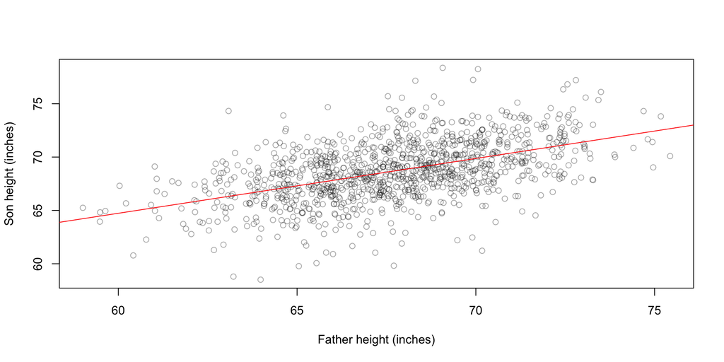

```r
# install.packages('UsingR')
suppressMessages(library(UsingR))
library(UsingR)  # Loads another collection of datasets
data(father.son)  # This is Pearson's data.
data = father.son
x1 = data$fheight  # fathers' heights
y = data$sheight  # sons' heights
plot(x1, y, xlab = "Father height (inches)", ylab = "Son height (inches)", col = adjustcolor("black",
    alpha.f = 0.35))
abline(lm(y ~ x1), col = "red")
```

- `x1` contains the fathers’ heights (independent/explanatory variable)
- `y` contains sons’ heights (dependent/response variable)

## Pearson’s correlation coefficient ($r$)

- It is the **mean** of the **product** of the variables in **standard units**, indicating both the sign and strength of the **linear association**.
  $$\widehat{r} = \frac{\sum_{i=1}^n (x_{1,i} - \bar{x}_1)(y_i - \bar{y})}{\sqrt{\sum_{i=1}^n (x_{1,i}-\bar{x}_1)^2} \sqrt{\sum_{i=1}^n (y_i - \bar{y})^2}}$$
- $x_{1,i}$ represents the i-th observed point of the 1st independent variable $x_1$.
- Later we will use this notation to handle multiple independent variables $x_1, x_2, \ldots, x_p$.

```r
cor(x1, y)
```

```
[1] 0.5013383
```

The correlation coefficient is **shift and scale invariant**.

```r
cor(0.2 * x1 + 3, 3 * y - 1)
```

```
[1] 0.5013383
```

The correlation coefficient is not affected by interchanging the variables.

```r
cor(y, x1)
```

```
[1] 0.5013383
```

## Regression line

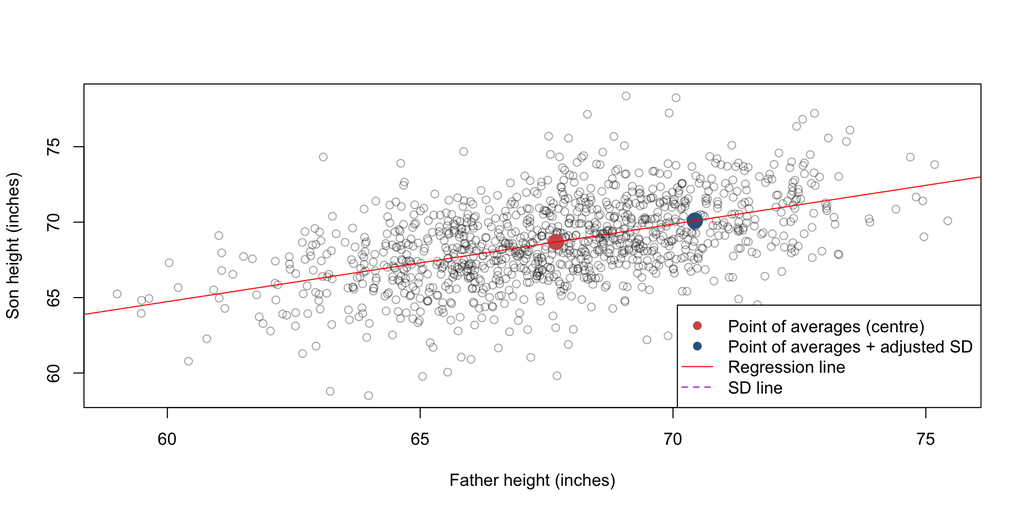

- The regression line $\hat{y} = \widehat{b}_0 + \widehat{b}_1 \cdot x_1$ connects $(\bar{x}_1, \bar{y})$ and $(\bar{x}_1 + \widehat{s}_{x_1}, \bar{y} + \widehat{r} \cdot \widehat{s}_{y})$ by estimating **regression corfficients**
  - the **slope** $\widehat{b}_1 = \widehat{r} \frac{\widehat{s}_{y}}{\widehat{s}_{x_1}}$ and the **intercept** $\widehat{b}_0 = \bar{y} - \widehat{b}_1 \cdot \bar{x}_1$.
- The **resisual** of the regression model
  $$e_{i} = y_i - \hat{y}_i = y_i - (\underbrace{\widehat{b}_0}_{\text{intercept}} + \underbrace{\widehat{b}_1}_{\text{slope}} x_{1,i}).$$
- We use $\widehat{s}_{x_1}$ and $\widehat{s}_y$ to denote sample SDs here, as $\sigma$ is used for the SD of residual later.

```r
model = lm(y ~ x1)
model
```

```
Call:
lm(formula = y ~ x1)

Coefficients:
(Intercept)           x1
    33.8866       0.5141
```

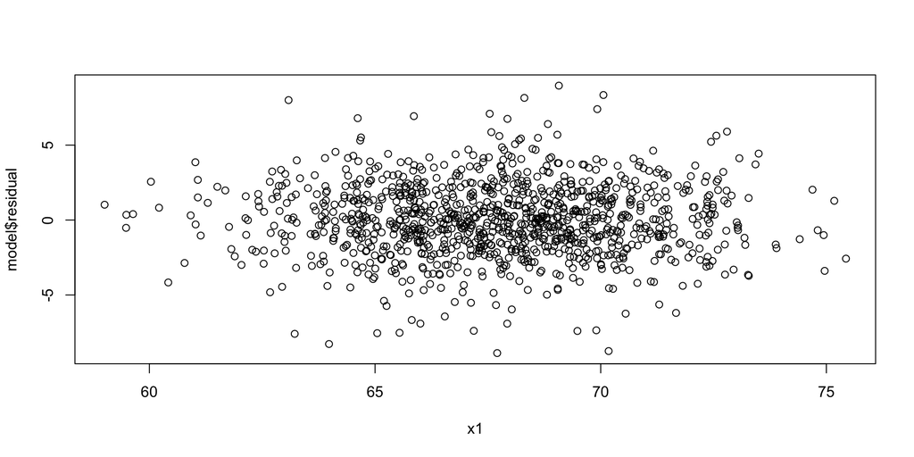

```r
plot(x1, model$residual)
```

- If the linear model is appropriate, the residual plot should be a random scatter of points.
- The variance of the random scatter should not change with the location of $x_1$ (**homoscedasticity**).

## Performance benchmark of linear regression model

- The regression line is the **best** (optimal) linear model, as it minimises the sum of the squared residuals $\sum_{i=1}^n e_i^2$ among all linear models (lines).
- We can use the **coefficient of determination** ($r^2$) to summarise the performance of a regression line.
  - The sum of squared residuals (or SSE for sum of squared errors) for the regression line
    $$\widehat{\text{SSE}} = \sum_{i = 1}^n e_i^2 = \sum_{i = 1}^n \Big(y_i - \underbrace{( \widehat{b}_0 + \widehat{b}_1 \cdot x_{1,i})}_{\hat{y}_i}\Big)^2$$
    measures **variation in $y$ left unexplained by the regression line**.
  - The sum of squared total variations (SST) of $y$ (sum of squared deviations)
    $$\widehat{\text{SST}} = \sum_{i = 1}^n (y_i - \bar{y})^2$$
    measures of **the total amount of variation in observed $y$ values** without relying on the independent variable $x_1$.
- **$\widehat{\text{SST}} \geq \widehat{\text{SSE}}$** as the regression is optimal for sum of squared errors
- The proportion of variation in the observed $y$ that **cannot** be explained by the simple linear regression model is given by
  $$\frac{\widehat{\text{SSE}}}{\widehat{\text{SST}}}$$
  which is always $\leq 1$.
- Thus, the proportion of variation in the observed $y$ that **can** be explained by the simple linear regression model (aka **coefficient of determination**) is
  $$\frac{\widehat{\text{SST}} - \widehat{\text{SSE}}}{\widehat{\text{SST}}} = 1 - \frac{\widehat{\text{SSE}}}{\widehat{\text{SST}}} = \widehat{r}^2$$
  - It is exactly the **squared correlation coefficient** (a number between 0 and 1) for simple linear regression models
- The higher the value of $\widehat{r}^2$, the more successful is the simple linear regression model in explaining variation of the dependent variable $y$.

## Possible extensions

- The correlation coefficient indicates the strength of the linear association of a sample.
  - Do the data suggest a significant linear association in the population?
  - We will extend the T-test to test this.
- What happen if we have multiple independent variables, $x_1, x_2, \ldots, x_p$?
  - We need to fit a linear model
    $$\hat{y} = \widehat{b}_0 + \widehat{b}_1 \cdot x_1 + \widehat{b}_2 \cdot x_2 + \cdots+ \widehat{b}_p \cdot x_p$$
  - How can we interpret this?
  - How to select the most relevant independent variables from $x_1, x_2, \ldots, x_p$ to achieve a similar performance as using all independent variables?

# Inference for simple linear regression models

## Probablistic view of simple linear regression models

The simple linear regression model aims to predict the outcome of a dependent/response variable, which is a random draw $Y$, using a independent/explanatory variable $x_1$ and the model
$$Y_i = \underbrace{b_0 + b_1 \cdot x_{1,i}}_{\text{the regression line}} + \varepsilon_i$$
for $i= 1, \ldots, n$ indexing an observation in the data set.

- The errors $\varepsilon_i$ are **random draws** taken from an “error box” with **mean $0$ and a fixed SD $\sigma$**.
- For any given $x_{1,i}$, the regression line $b_0 + b_1 \cdot x_{1,i}$ is the expected value of $Y_i$.
  - The intercept is the expected value of $Y_i$ when $x_1 =0$.
  - The slope is the amount we expect $Y$ to change by when $x_1$ increases one unit,
    - i.e. for a one unit increase in $x_1$ we expect $Y$ to change by $b_1$ (could be an increase or decrease depending on the sign) in average.
- We estimate the population intercept and slope $(b_0,b_1)$ using observed $(x_{1,i}, y_i), i = 1, \ldots, n$.

## Assumptions

$\fbox{A}$ We make the following assumptions:

- The errors $\varepsilon_i$ are **independently** drawn from an “error box” with mean $0$ and SD $\sigma$.
  - So the variability of $\varepsilon_i$ does not depend on $x$ (and thus homoscedasticity).
  - We can check the residual plot for this.
- In addition, the **“error box” should be normal-shaped**.
  - The estimated coefficients $(\widehat{b}_0, \widehat{b}_1)$ not only give the best line fitting the observed sample (in terms of minimizing the sum of squared residuals);
  - but also correctly estimate of the population coefficients $(b_0, b_1)$ in expectation (the derivation is beyond the scope here).
  - Use the QQ plot to check normality.
- **Linearity:** should be checked using graphical summaries.
  - Either the scatter plot or the residual plot can be used for this (see Topic 4).
- For the first two assumptions, we simply write $\varepsilon_i \sim \text{(iid)}\; N(0, \sigma^2)$.

## Normality of Pearson’s data

```r
qqnorm(model$residual)
qqline(model$residual)
```

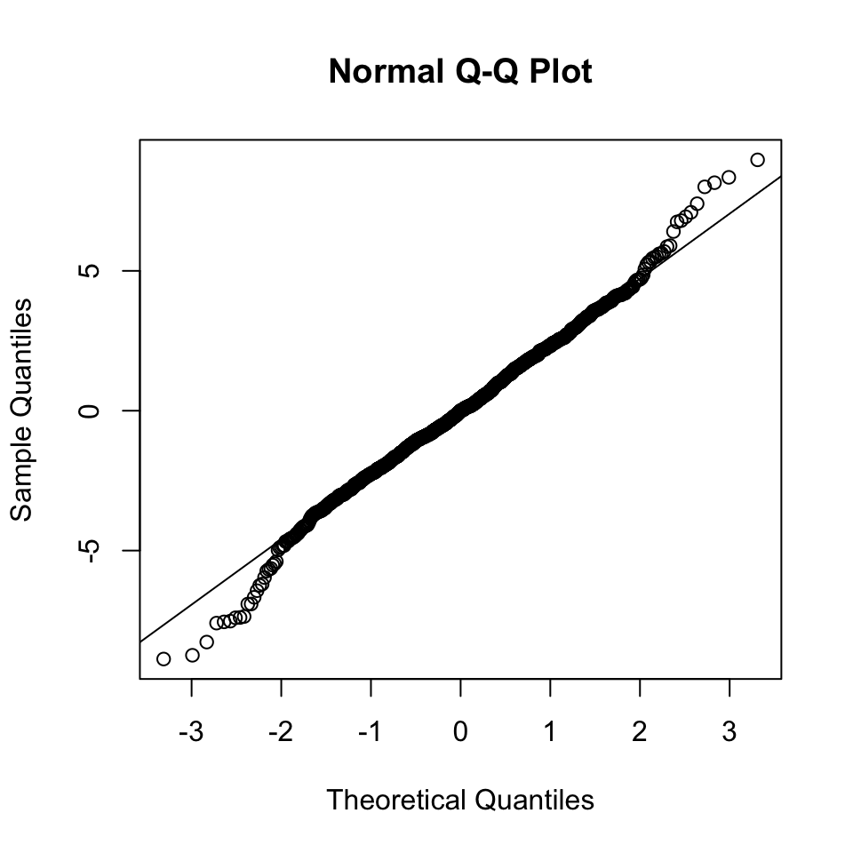

- slight deviations away from the qqline towards the tails, but not bad.

## Inference: T-test

Recall the population model for simple linear regression
$$Y_i = b_0 + b_1 \cdot x_{1,i} + \varepsilon_i, \quad \varepsilon_i \sim \text{(iid)}\; N(0, \sigma^2)$$
$\fbox{H}$ Typically, we are interested in the hypotheses

- $H_0: b_1 = 0$ there is no linear relationshop between $x$ and $Y$.
- Alternatives:
  - $H_1: b_1 \neq 0$: there is linear relationshop between $x$ and $Y$.
  - $H_1: b_1 > 0$ (or $b_1 < 0$): there is positive (or negative) linear relationshop between $x$ and $Y$.

$\fbox{T}$ To do this, we use a T-statistic
$$T = \frac{\widehat{b}_1 - b_1}{\widehat{SE}(\widehat{b}_1)} = \frac{\widehat{b}_1}{\widehat{SE}(\widehat{b}_1)} \sim t_{n-2}$$

- What is the (estimated) standard error of the slope estimate $\widehat{SE}(\widehat{b}_1)$?
- Why does the Student’s $t$-distribution have $n-2$ degrees of freedom?

## Standard error of slope estimate $SE(\widehat{b}_1)$

- This derivation (three slides) is NOT for assessment!
- Fixing $x_{1,i}$, estimated slope $\widehat{b}_1$ can be viewed as a random draw depending on $Y_i$
  $$\widehat{b}_1 = \widehat{r} \times \frac{\widehat\sigma_Y}{\widehat\sigma_X} = \frac{\sum_{i=1}^n (x_{1,i} - \bar{x}_1)(Y_i - \bar{Y})}{\sqrt{\sum_{i=1}^n (x_{1,i}-\bar{x}_1)^2} \sqrt{\sum_{i=1}^n (Y_i - \bar{Y})^2}} \times \frac{\sqrt{\frac{1}{n-1}\sum_{i=1}^n (Y_i - \bar{Y})^2}}{\sqrt{\frac{1}{n-1}\sum_{i=1}^n (x_i - \bar{x})^2}}$$
  which gives (using the population model $Y_i = b_0 + b_1 \cdot x_i + \varepsilon_i$)
  $$\widehat{b}_1 = \frac{\sum_{i=1}^n (x_{1,i} - \bar{x}_1)(Y_i - \bar{Y})}{\sum_{i=1}^n (x_{1,i}-\bar{x}_1)^2 } = \frac{\sum_{i=1}^n (x_{1,i} - \bar{x}_1)(b_0 + b_1 \cdot x_i + \varepsilon_i - \bar{Y})}{(n-1)\widehat{s}_X^2}$$
- Recall that $\sum_{i=1}^n (x_{1,i} - \bar{x}_1) = 0$, so
  $$\sum_{i=1}^n (x_{1,i} - \bar{x}_1)(b_0 + b_1 \cdot x_i + \varepsilon_i - \bar{Y}) = \sum_{i=1}^n (x_{1,i} - \bar{x}_1)(b_1 \cdot (x_i - \bar{x}) + \varepsilon_i)$$

  as we can add or substact constants in the second bracket without changing the numerator
- Then, we have the slope estimate
  $$\widehat{b}_1 = \frac{ b_1 \sum_{i=1}^n (x_{1,i} - \bar{x}_1)^2 + \sum_{i=1}^n (x_{1,i} - \bar{x}_1) \varepsilon_i}{(n-1)\widehat{s}_X^2} = b_1 + \frac{\sum_{i=1}^n (x_{1,i} - \bar{x}_1) \varepsilon_i}{(n-1)\widehat{s}_X^2}$$
- Rearranging, we have
  $$\widehat{b}_1 - b_1 = \sum_{i=1}^n \underbrace{\left( \frac{x_{1,i} - \bar{x}_1}{(n-1)\widehat{s}_X^2} \right)}_{w_i} \varepsilon_i = \sum_{i=1}^n w_i \cdot \varepsilon_i$$
  where the weights $w_i$ only depend on observations of the independent variable $x_1$.
- The linear combination $\widehat{b}_1 - b_1 = \sum_{i=1}^n w_i \cdot \varepsilon_i$ also follows a normal curve and has
  - Expected value: $\sum_{i=1}^n w_i \cdot E(\varepsilon_i) = 0$
  - Squared standard error:
    $$\sum_{i=1}^n w_i^2 \cdot SE(\varepsilon_i)^2 = \sum_{i=1}^n w_i^2 \cdot \sigma^2 = \sigma^2 \sum_{i=1}^n w_i^2$$
- This way,
  $$SE(\widehat{b}_1 - b_1)^2 = \sigma^2 \sum_{i=1}^n w_i^2 = \sigma^2 \sum_{i=1}^n \left( \frac{x_{1,i} - \bar{x}_1}{(n-1)\widehat{s}_X^2}\right)^2 = \sigma^2 \frac{\sum_{i=1}^n (x_{1,i} - \bar{x}_1)^2}{\left((n-1)\widehat{s}_X^2\right)^2}$$
- Since $\sum_{i=1}^n (x_{1,i} - \bar{x}_1)^2 = (n-1)\widehat{s}_X^2$, it gives
  $$SE(\widehat{b}_1 - b_1)^2 = \frac{\sigma^2}{(n-1)\widehat{s}_X^2}$$
  and
  $$SE(\widehat{b}_1 - b_1)=\frac{\sigma}{\sqrt{\sum_{i=1}^n (x_{1,i} - \bar{x}_1)^2}}$$
- Since adding constant to a random draw does not change its standard error (as the SD of the box remains the same), we have
  $$SE(\widehat{b}_1)=\frac{\sigma}{\sqrt{\sum_{i=1}^n (x_{1,i} - \bar{x}_1)^2}}$$

## Estimate $SE(\widehat{b}_1)$ from an observed sample

- We need to estimate $\sigma$ (the population SD of the error box for $\varepsilon_i$) to get $\widehat{SE}(\widehat{b}_1)$. But what is a sensible estimate for $\sigma$?
  $$\widehat\sigma = \sqrt{\frac{1}{n-2}\sum_{i=1}^n \left(y_i - (\hat{b}_0 + \hat{b_1}\cdot x_{1,i})\right)^2} = \sqrt{\frac{\widehat{\text{SSE}}}{n-2}}$$
  We lose **two** degrees of freedom for estimating two parameters (the intercept and the slope).
- **For multiple independent variables, $x_1, x_2, \ldots, x_p$, since we need to estimate $p+1$ parameters (+1 for the intercept), the degrees of freedom for estimating $\widehat\sigma$ is $n-(p+1)$.**
- In summary, we have
  $$\widehat{SE}(\widehat{b}_1) = \sqrt{\frac{1}{n-(p+1)} \frac{\sum_{i=1}^n \left(y_i - (\hat{b}_0 + \hat{b_1}\cdot x_{1,i})\right)^2}{\sum_{i=1}^n (x_{1,i} - \bar{x}_1)^2} }$$

## T-statistic

$\fbox{T}$ The T-statistic for the estimated slope takes the form
$$T = \frac{\widehat{b}_1 - b_1}{\widehat{SE}(\widehat{b}_1)} \sim t_{n-(p+1)}$$
where
$$\widehat{SE}(\widehat{b}_1) = \sqrt{\frac{1}{n-(p+1)} \frac{\text{sum of squared residual}}{\text{sum of squared deviations in }x_1}}$$

- For simple linear regression models, $p = 1$

## Pearson’s data

- Estimate $\widehat\sigma$ and $\widehat{SE}(\widehat{b}_1)$

```r
n = length(x1)  # sample size
n
```

```
[1] 1078
```

```r
sse = sum(model$residual^2)
sig.hat = sqrt(sse/(n - 2))  # estimated SD of the error model
round(sig.hat, 3)
```

```
[1] 2.437
```

```r
dev.x = x1 - mean(x1)
sqrt.sum.sq.dev = sqrt(sum(dev.x^2))  # sqrt of sum of squared deviations in x1
est.se = sig.hat/sqrt.sum.sq.dev
round(est.se, 5)
```

```
[1] 0.02705
```

- Calculate the coefficient of determination ($r^2$)

```r
round(cor(x1, y)^2, 4)
```

```
[1] 0.2513
```

- Calculate observed test statistic and two-sided P-value

```r
b1.hat = model$coefficients[2]  # the second parameter is the slope
stat = b1.hat/est.se
round(stat, 2)
```

```
   x1
19.01
```

```r
p.value = 2 * pt(abs(stat), df = n - 2, lower.tail = F)
p.value
```

```
          x1
1.121268e-69
```

- P-value for the slope is close to zero, which rejects $H_0$ for most commonly used false alarm rates;
  - indirectly suggests that there is linear relationshop between $x$ (father’s height) and $Y$ (son’s height) in the population.

## Use `summary(model)`

```r
summary(model)  # where model = lm (y ~ x1)
```

```
Call:
lm(formula = y ~ x1)

Residuals:
    Min      1Q  Median      3Q     Max
-8.8772 -1.5144 -0.0079  1.6285  8.9685

Coefficients:
            Estimate Std. Error t value Pr(>|t|)
(Intercept) 33.88660    1.83235   18.49   <2e-16 ***
x1           0.51409    0.02705   19.01   <2e-16 ***
---
Signif. codes:  0 '***' 0.001 '**' 0.01 '*' 0.05 '.' 0.1 ' ' 1

Residual standard error: 2.437 on 1076 degrees of freedom
Multiple R-squared:  0.2513,    Adjusted R-squared:  0.2506
F-statistic: 361.2 on 1 and 1076 DF,  p-value: < 2.2e-16
```

- **2nd row below** `Coefficients` shows the slope $\widehat{b}_1$, $\widehat{SE}(\widehat{b}_1)$, observed T-statistics, and two-sided P-value
- **3rd row from the bottom** shows
  - the estimated SD of the error model, $\widehat\sigma$, which is the SE of the residual $\varepsilon_i$;
  - and the degrees of freesom $n-(p+1)$.
- **2nd row from the bottom** shows the `Multiple R-squared`, which is the coefficient of determination

## Confidence intervals for regression corfficients

- Confidence intervals (e.g., 99%) for regression corfficients can be constructed in the usual way
- Find (symmetric) multipliers $-\ell = u$ such that
  $$P\left( \ell \leq \frac{\widehat{b}_1 - b_1}{\widehat{SE}(\widehat{b}_1)} \leq u \right) = 0.99, \quad T = \frac{\widehat{b}_1 - b_1}{\widehat{SE}(\widehat{b}_1)} \sim t_{n-{p+1}}$$
- $u$ is given as the 99.5% quantile (the 0.5% percentage point in the upper tail)

```r
u = qt(0.995, df = n - 2)
u
```

```
[1] 2.580406
```

```r
round(b1.hat + c(-1, 1) * u * est.se, 3)
```

```
[1] 0.444 0.584
```

which does not contain zero (again, reject $H_0$ at the 1% level of significance).

## P-values mean nothing if you haven’t looked your data

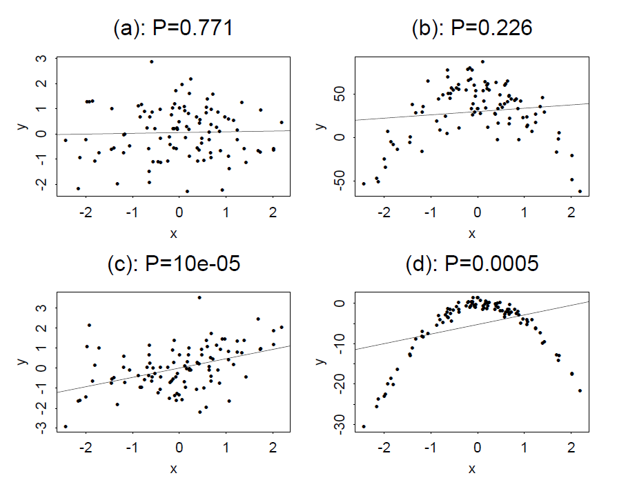

# Case study

## Air pollution

The data frame `environmental` has four environmental variables `ozone`, `radiation`, `temperature` and `wind` taken in New York City from May to September of 1973.

```r
data("environmental", package = "lattice")
# ?environmental
dim(environmental)
```

```
[1] 111   4
```

```r
str(environmental)
```

```
'data.frame':   111 obs. of  4 variables:
 $ ozone      : num  41 36 12 18 23 19 8 16 11 14 ...
 $ radiation  : num  190 118 149 313 299 99 19 256 290 274 ...
 $ temperature: num  67 72 74 62 65 59 61 69 66 68 ...
 $ wind       : num  7.4 8 12.6 11.5 8.6 13.8 20.1 9.7 9.2 10.9 ...
```

We’d like to assess whether the maximum daily temperature ($x$) has an influence on average ozone concentration ($Y$). - Let’s use the 1% level of significance.

$\fbox{H}$ for the simple linear regression model: $Y_i = b_0 + b_1\cdot x_{1,i} + \varepsilon_i$

- $H_0: b_1 = 0$ – temperature has no linear association with ozone concentration
- $H_1: b_1 \neq 0$ – temperature has a linear association with ozone concentration

## $\fbox{A}$ checking assumptions

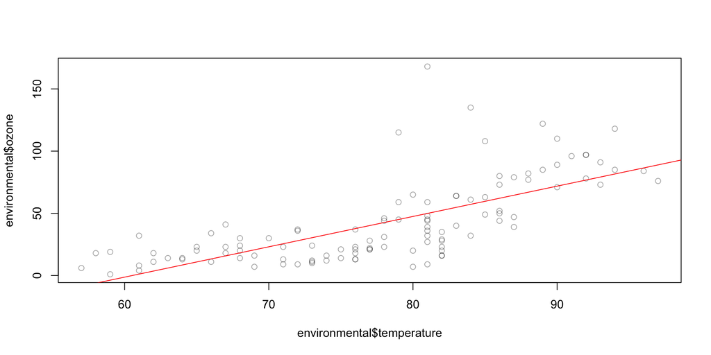

```r
plot(environmental$temperature, environmental$ozone, col = adjustcolor("black", alpha.f = 0.35))
lm1 = lm(ozone ~ temperature, environmental)
abline(lm1, col = "red")
```

- `lm(ozone ~ temperature, data=environmental)` fits a linear regression model with response variable `ozone`, explanatory variable `temperature`, and both are taken from the data frame `environmental`

## $\fbox{A}$ linearity

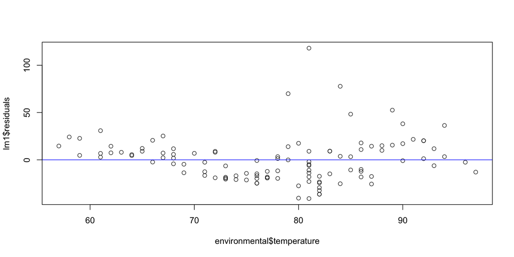

```r
plot(environmental$temperature, lm1$residuals, col = adjustcolor("black", alpha.f = 0.85))
abline(h = 0, col = "blue")
```

The residuals are above zero for low temperatures, then they go below zero for moderate temperatures, and end up again above zero for high temperatures.

- Our predictions are **systematically wrong** for certain ranges of temperature: **underestimate** the ozone level for low and high temperatures and **overestimate** the ozone level at moderate temperatures.

## Transformation

- If the linearity assumption fails, there’s not much point checking the other assumptions because it’s not an appropriate prediction model.
- If we see a non-linear relationship between $y$ and $x$ we might be able to transform the data so that we have a linear relationship between the transformed variable(s).
  - What if we considered the log of ozone concentration?

```r
env.new = environmental  # create a new data frame
env.new[, "log.ozone"] = log(environmental$ozone)  # add a new variable log.ozone
env.new[, "ozone"] = NULL  # delete the old variable ozone
```

```r
lm2 = lm(log.ozone ~ temperature, env.new)
lm2
```

```
Call:
lm(formula = log.ozone ~ temperature, data = env.new)

Coefficients:
(Intercept)  temperature
   -1.84852      0.06767
```

Now the fitted model is:
$$\widehat{\log(\text{ozone})} = \underbrace{-1.84852}_{\widehat{b}_0} + \underbrace{0.06767}_{\widehat{b}_1}\times\text{temperature}$$

## $\fbox{A}$ linearity

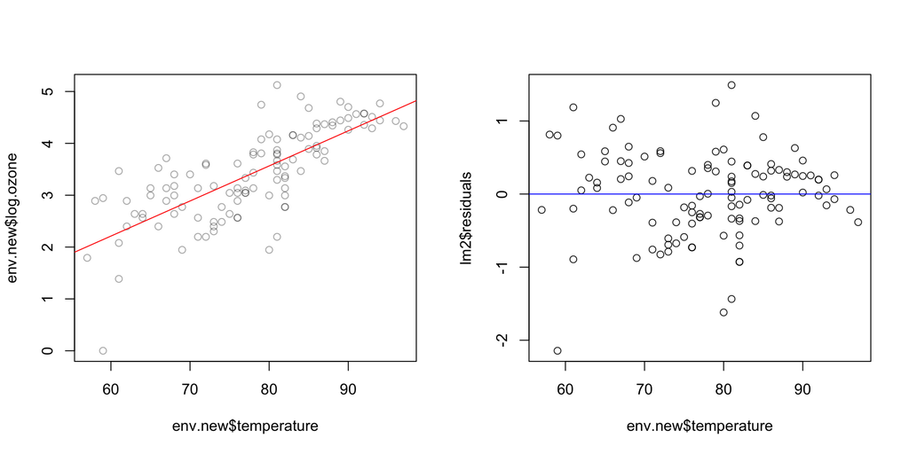

```r
par(mfrow = c(1, 2))
plot(env.new$temperature, env.new$log.ozone, col = adjustcolor("black", alpha.f = 0.35))
abline(lm2, col = "red")
plot(env.new$temperature, lm2$residuals, col = adjustcolor("black", alpha.f = 0.85))
abline(h = 0, col = "blue")
```

- No more over- and under-estimates. It seems that linearity holds between $\log(\text{ozone})$ and $\text{temperature}$.

## $\fbox{A}$ independence and homoscedasticity

- The assumption of independence between the errors is usually dealt with in the experimental design phase - **before data collection**.
  - We didn’t cover the design the experiment in this unit (let’s skip this one).

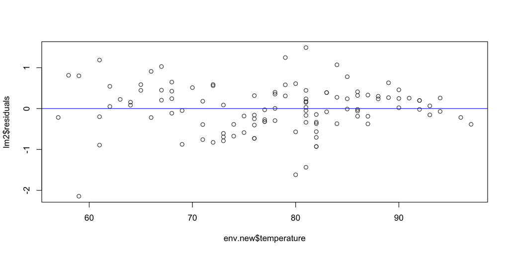

```r
plot(env.new$temperature, lm2$residuals, col = adjustcolor("black", alpha.f = 0.85))
abline(h = 0, col = "blue")
```

- Is the data homoscedastic? The spread looks reasonably constant over the range of temperature values.
  - In the region above 85°F, the spread might be somewhat smaller than the spread in the region below 85°F but it’s nothing to get too worried about.

## $\fbox{A}$ normality

```r
qqnorm(lm2$residual)
qqline(lm2$residual)
```

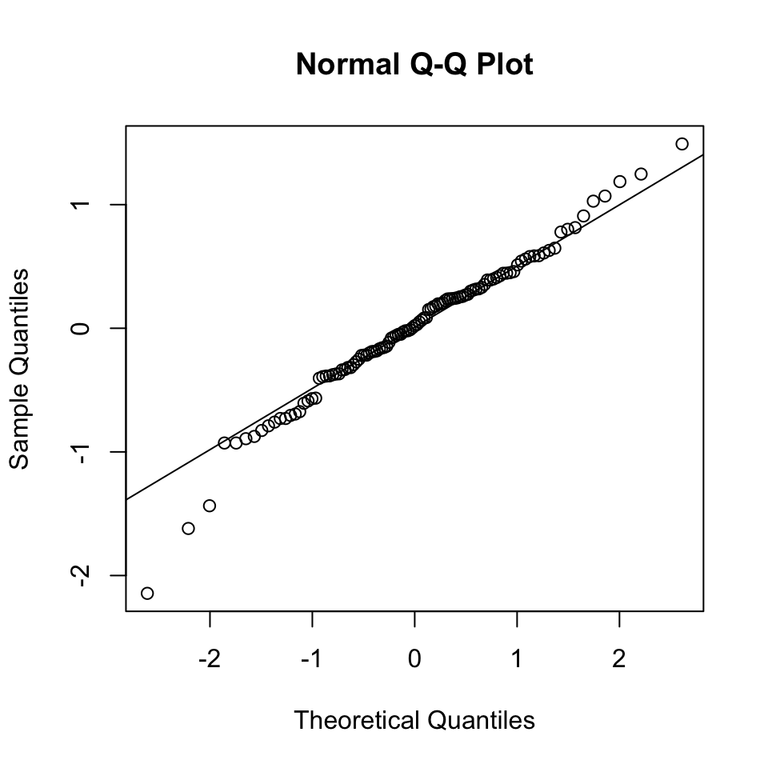

- Apart from three points in the lower tail, the majority of the points lie quite close to QQ line. Hence, the normality assumption for the residuals is reasonably well satisfied.

## How can we interpret the estimated coefficients?

$$Y_i = b_0 + b_1 x_{1,i} + \varepsilon_i$$

- The intercept is the expected value of $Y_i$ when $x_1=0$.
- The slope is the amount we expect $Y$ to change by when $x_1$ increases one unit, i.e. for a one unit increase in $x_1$ we expect $Y$ to change by $b_1$ (could be an increase or decrease depending on the sign).
- However, recall our fitted model
  $$\widehat{\log(\text{ozone})} = \underbrace{-1.84852}_{\widehat{b}_0} + \underbrace{0.06767}_{\widehat{b}_1}\times\text{temperature}$$
- How do we interpret this model?

## Slope interpretation

$$\widehat{\log(\text{ozone})} = -1.84852 + 0.06767\times\text{temperature}$$

- Consider two temperatures: $\text{temperature}_2 - \text{temperature}_1 = 1$, their corresponding predicted log ozone values have the difference
  $$\widehat{\log(\text{ozone})}_2 - \widehat{\log(\text{ozone})}_1 = 0.06767\times(\text{temperature}_2 - \text{temperature}_1) \approx 0.07,$$
  - Interpreting the slope: a one degree increase in temperature results in a 0.07 unit **increase** in log ozone, on average.
- The ratio between two ozone readings can be approximated by
  $$\frac{\widehat{\text{ozone}}_2}{\widehat{\text{ozone}}_1} = \exp\left(\widehat{\log(\text{ozone})}_2 - \widehat{\log(\text{ozone})}_1 \right) \approx \exp(0.07) \approx 1 + 0.07$$
- A nicer way to interpret this is: a one degree increase in temperature results in an approximate 7% **increase** in ozone, on average.
- In general, for log-linear models $\log(Y) = b_0 + b_1 \cdot x_1$,
  - On average, a one unit increase in $x_1$ will result in a $b_1\%$ change in $Y$ (only works for small $b_1$).

## Inference on the slope coefficient

```r
summary(lm2)
```

```
Call:
lm(formula = log.ozone ~ temperature, data = env.new)

Residuals:
     Min       1Q   Median       3Q      Max
-2.14417 -0.32555  0.02066  0.34234  1.49100

Coefficients:
             Estimate Std. Error t value Pr(>|t|)
(Intercept) -1.848518   0.455080  -4.062  9.2e-05 ***
temperature  0.067673   0.005807  11.654  < 2e-16 ***
---
Signif. codes:  0 '***' 0.001 '**' 0.01 '*' 0.05 '.' 0.1 ' ' 1

Residual standard error: 0.5804 on 109 degrees of freedom
Multiple R-squared:  0.5548,    Adjusted R-squared:  0.5507
F-statistic: 135.8 on 1 and 109 DF,  p-value: < 2.2e-16
```

$\fbox{T}$ observed T-statistics $t = 11.654$, d.f. $=109$

$\fbox{P}$ the P-value is $< 2e-16$ for the two-sided alternative

$\fbox{C}$ We reject $H_0$ at the 1% level of significance, suggesting there is a linear association between log ozone and temperature

# Multiple linear regression models

## Air pollution

The coefficient of determination ($r^2$) in the ozone example is 0.5548. - We can say that temperature explains 55% of the observed variation in the logarithm of ozone concentration.

**Can we do better if we use more variables to help explain the logarithm of ozone concentration?**

```r
dim(env.new)
```

```
[1] 111   4
```

```r
str(env.new)
```

```
'data.frame':   111 obs. of  4 variables:
 $ radiation  : num  190 118 149 313 299 99 19 256 290 274 ...
 $ temperature: num  67 72 74 62 65 59 61 69 66 68 ...
 $ wind       : num  7.4 8 12.6 11.5 8.6 13.8 20.1 9.7 9.2 10.9 ...
 $ log.ozone  : num  3.71 3.58 2.48 2.89 3.14 ...
```

## Pairwise scatter plot

```r
pairs(env.new)
```

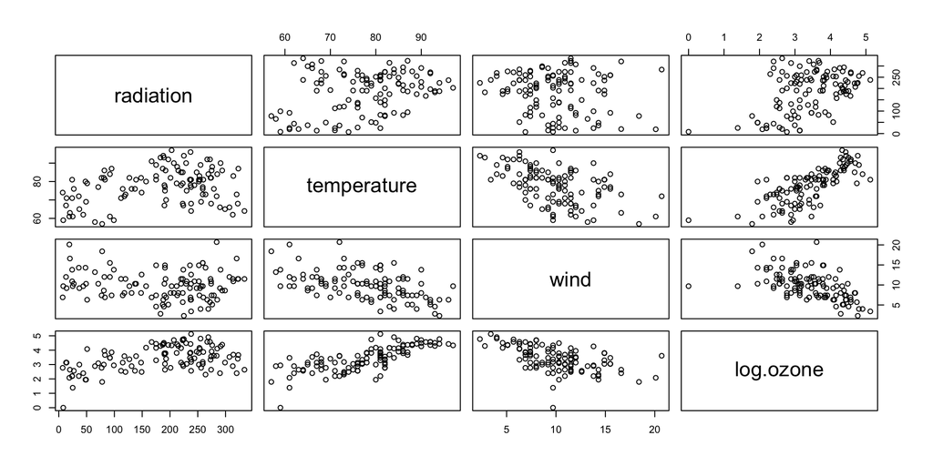

## Pairwise correlation

```r
round(cor(env.new), 2)
```

```
            radiation temperature  wind log.ozone
radiation        1.00        0.29 -0.13      0.46
temperature      0.29        1.00 -0.50      0.74
wind            -0.13       -0.50  1.00     -0.56
log.ozone        0.46        0.74 -0.56      1.00
```

- The variable `log.ozone` appears to be positively associated with `temperature`, negatively associated with `wind`, and and (moderately) positively associated with `radiation`.

## Model

Can `radiation`, `temperature` and `wind` be used to predict `log.ozone`?

$$\log(\text{ozone})_i = b_0 + b_1 \cdot \text{radiation}_i + b_2 \cdot \text{temperature}_i + b_3 \cdot \text{wind}_i + \varepsilon_i$$

```r
lm3 = lm(log.ozone ~ radiation + temperature + wind, env.new)
round(summary(lm3)$coefficients, 3)
```

```
            Estimate Std. Error t value Pr(>|t|)
(Intercept)   -0.261      0.553  -0.472    0.638
radiation      0.003      0.001   4.518    0.000
temperature    0.049      0.006   8.078    0.000
wind          -0.062      0.016  -3.922    0.000
```

Fitted model:
$$\widehat{\log(\text{ozone})} = -0.261 + 0.003 \cdot \text{radiation} + 0.049 \cdot \text{temperature} - 0.062 \cdot \text{wind}$$

## Multiple linear regression model

Multiple linear regression is a natural extension of simple linear regression that incorporates multiple explanatory (or predictor) variables. It has the general form,
$$Y_i = b_0 + b_1 \cdot x_{1,i} + b_2 \cdot x_{2,i} + \ldots + b_p \cdot x_{p,i} + \varepsilon_i, \text { where }\varepsilon_i \sim (\text{iid})\; N(0,\sigma^2).$$

- The same assumption on $\varepsilon_i$ as in the simple linear regression case.

Often it’s convenient to write the model in matrix format,

$$\boldsymbol{Y} = \boldsymbol{X}\boldsymbol{\beta} + \boldsymbol{\varepsilon}$$
where $\boldsymbol{Y} = (Y_1, Y_2, \ldots, Y_n)'$, $\boldsymbol{\beta} = (b_0, b_1,b_2,\ldots, b_p)'$, $\boldsymbol{\varepsilon} \sim N_n(\mathbf{0}, \sigma^2\boldsymbol{I})$ and
$$\boldsymbol{X} = \left[\begin{array}{c}
\boldsymbol{x}_1' \\
\boldsymbol{x}_2' \\
\vdots \\
\boldsymbol{x}_n'
\end{array}\right] = \left[\begin{array}{ccccc}
1 & x_{11} & x_{12} & \ldots & x_{1p} \\
1 & x_{21} & x_{22} & \ldots & x_{2p} \\
\vdots & \vdots & \vdots & & \vdots \\
1 & x_{n1} & x_{n2} & \ldots & x_{np}
\end{array}\right],$$
is the **design matrix** depending on observed independent variables, where $\boldsymbol{x}_i = (1, x_{i1}, x_{i2}, \ldots, x_{ip})$ is the vector of predictors for the $i$th observation.

## Fitting a multiple linear regression model

The optimal fit (least squares solution) is:
$$\left[\begin{array}{c}
\widehat{b}_0 \\
\widehat{b}_1 \\
\vdots \\
\widehat{b}_p
\end{array}\right] = \Large \widehat{\boldsymbol{\beta}} = (\boldsymbol{X}'\boldsymbol{X})^{-1}\boldsymbol{X}'\boldsymbol{y}$$
which gives the coefficients that minimise the sum of squared residuals $\sum_{i=1}^n = e_i^2$ where the residual is defined as
$$e_i = y_i - \underbrace{(\widehat{b}_0 + \widehat{b}_1 \cdot x_{1,i} + \widehat{b}_2 \cdot x_{2,i} + \ldots + \widehat{b}_p \cdot x_{p,i})}_{\text{fitted regression model } \widehat{y}_i}$$

- We will only consider using R to solve this for obtaining the estimated regression coefficients.

## Interpretation

The estimated coefficients ( $\widehat{b}$’s ) are now interpreted as **conditional on** the other variables

- each $\widehat{b}_j$ reflects the predicted change in $y$ associated with a one unit increase in the independent variable $x_j$, holding the other variables constant.

$$\widehat{\log(\text{ozone})} = -0.261 + 0.003 \cdot \text{radiation} + 0.049 \cdot \text{temperature} - 0.062 \cdot \text{wind}$$

- A one degree (Fahrenheit) increase in temperature results in a 4.9% **increase** in ozone on average, holding radiation and wind speed constant.
- A one langley increase solar radiation results in a 0.3% **increase** in ozone on average, holding radiation and wind constant.
- A one mile per hour increase in average wind speed results in a 6.2% **decrease** in ozone on average, holding radiation and temperature constant.

## Coefficient of determination

The coefficient of determination ($r^2$) value has the same interpretation: proportion of total variability in $Y$ explained by the regression model.

- Simple linear regression model

```r
summary(lm2)$r.squared
```

```
[1] 0.5547615
```

- “Full” model

```r
summary(lm3)$r.squared
```

```
[1] 0.664515
```

- Including more parameters can better explain the dependent variable.
- Note that for multiple linear regression, we can use $1 - \frac{\widehat{\text{SSE}}}{\widehat{\text{SST}}}$ to calculate $r^2$.

```r
SSE = sum(lm3$residuals^2)
SST = sum((env.new$log.ozone - mean(env.new$log.ozone))^2)
1 - SSE/SST
```

```
[1] 0.664515
```

- However, we cannot obtain $r^2$ by simply summing the squared correlation coefficients; in fact, it is the squared correlation between the fitted model $\widehat{y}_i$ and the observed data $y_i$ (let’s skip this).

## Inference on regression coefficients

- We can also use the T test on regression coefficients in multiple regression.

$$Y_i = b_0 + b_1 \cdot x_{1,i} + b_2 \cdot x_{2,i} + \ldots + b_p \cdot x_{p,i} + \varepsilon_i, \text { where }\varepsilon_i \sim (\text{iid})\; N(0,\sigma^2).$$

- The T-test aims at testing if independent variable $x_j$ has a significant linear relationship with the dependent variable $Y$, after adjusting for all other independent variables in the model.
  - In other words, after considering all other independent variables $x_1, x_2, \ldots, x_{j-1}, x_{j+1}, \ldots, x_p$ (as well as the intercept), we want to test if there is a linear relationship between $x_j$ and $Y$.
- Equivalently, taking the effect of all other independent variables out of the dependent variable
  $$U_i = Y_i - (b_0 + b_1 \cdot x_{1,i} + \cdots + b_{j-1} \cdot x_{j-1,i} + b_{j+1} \cdot x_{j+1,i} + \cdots + b_p \cdot x_{p,i})$$
  we have the new model
  $$U_i = b_j \cdot x_{j,i} + \varepsilon_i, \text { where }\varepsilon_i \sim (\text{iid})\; N(0,\sigma^2)$$
  and want to test if there is a linear relationship between $x_j$ and $U$.

Let’s consider `wind` ($x_3$) and a two-sided alternative as an example, using the 1% level of significance.

- $\fbox{H}$ hypotheses
  - $H_0: b_3 = 0$ – after adjusting for all other independent variables, there is no linear relationship between `wind` and `log.ozone`
  - $H_1: b_3 \neq 0$ – after adjusting for all other independent variables, there is a linear relationship between `wind` and `log.ozone`
- $\fbox{T}$ The test statistic is
  $$T = \frac{\widehat{b}_3 - b_3}{\widehat{SE}(\widehat{b}_3)} \sim t_{n-(p+1)}$$
  where $b_3 = 0$ under $H_0$ and $p = 3$; however, the estimated standard error takes a slightly different form
  $$\widehat{SE}(\widehat{b}_3) = \widehat\sigma \times \sqrt{[(\boldsymbol{X}'\boldsymbol{X})^{-1}]_{33}}$$
  - as before, we have the estimated SD of the residual error $\widehat\sigma = \sqrt{\frac{1}{n-(p+1)} \sum_{i=1}^n (y_i - \hat{y}_i)^2} = \sqrt{\frac{1}{n-(p+1)} SSE}$
  - the term $[(\boldsymbol{X}'\boldsymbol{X})^{-1}]_{33}$ is the last element of the matrix $(\boldsymbol{X}'\boldsymbol{X})^{-1}$
    - is analogous to $1/\sqrt{\sum_{i=1}^n(x_{1,i} - \bar{x}_1)^2}$ in the simple linear regression case (see Page 18);
    - but counting the linear dependency among all independent variables (the derivation is beyond the scope here)
  - so, we rely on the R function `summary()` to work this out.

```r
dim(env.new)
```

```
[1] 111   4
```

```r
summary(lm3)
```

```
Call:
lm(formula = log.ozone ~ radiation + temperature + wind, data = env.new)

Residuals:
     Min       1Q   Median       3Q      Max
-2.06212 -0.29968 -0.00223  0.30767  1.23572

Coefficients:
              Estimate Std. Error t value Pr(>|t|)
(Intercept) -0.2611739  0.5534102  -0.472 0.637934
radiation    0.0025147  0.0005567   4.518 1.62e-05 ***
temperature  0.0491630  0.0060863   8.078 1.07e-12 ***
wind        -0.0615925  0.0157037  -3.922 0.000155 ***
---
Signif. codes:  0 '***' 0.001 '**' 0.01 '*' 0.05 '.' 0.1 ' ' 1

Residual standard error: 0.5085 on 107 degrees of freedom
Multiple R-squared:  0.6645,    Adjusted R-squared:  0.6551
F-statistic: 70.65 on 3 and 107 DF,  p-value: < 2.2e-16
```

## Warning: dangers of multicollinearity

When some of the independent variables are highly correlated (multicollinearity) then we can find that the fitted multiple regression models can have

- $\widehat{b}_j$ coefficients with counter-intuitive signs;
- terms with large estimated standard errors $\widehat{SE}(\widehat{b}_j)$; and
- rather large (counter-intuitive) P-values.

Often removing some of the independent variables

- changes all of the above with very little impact on the coefficient of determination $(r^2)$
- This comes from the fact that $\widehat{b}_j$ reflects the additional information provided by variable $x_j$ given that all the other variables have been fitted.

See the lab today and more examples next week.

# Assessment expectations

## Assessment expectations

- Simple linear regression
  - Know how to work out the slope and intercept
  - Know how to work out the coefficient of determination $r^2$ given the correlation coefficient
- Multiple linear regression
  - We will rely on R outputs for both the regression coefficients and $r^2$
- T-test for simple and multiple linear regression
  - We don’t expect you to work out standard errors of the estimated regression coefficients by hand;
  - but given the estimated regression coefficients and standard errors, you should be able to work out the test statistic and P-value.
  - Know how to get the degrees of freedom, $n-(p+1)$, for estimating the SD of the residual error, and hence the degrees of freedom to be used in Student’s $t$-distribution.